# NDVI_exploration

Nicole

3/21/2022

```r
library("tidyr")
library("dplyr")
library("readr")
library("ggplot2")
library("ggbreak")
library("patchwork")
library("ggpubr")
```

```r
MyMerge       <- function(x, y){
  df            <- merge(x, y, all = TRUE)
  rownames(df)  <- df$Row.names
  df$Row.names  <- NULL
  return(df)
}
```

# Team vole NDVI/COVER

## Load in NDVI data

```r
TV_NDVI_orig_2021 <- read.csv("../Data/2021_Toolik_NDVI.csv", header = TRUE)
TV_NDVI_orig_2020 <- read.csv("../Data/2020_Toolik_NDVI.csv", header = TRUE)
TV_NDVI_orig_2019 <- read.csv("../Data/2019_Toolik_NDVI.csv", header = TRUE)
TV_NDVI_orig_2018 <- read.csv("../Data/2018_Toolik_NDVI.csv", header = TRUE)
```

## Prep the Team Vole NDVI data

Remove data we don’t need

```r
TV_NDVI_clean_2021 <-  TV_NDVI_orig_2021 %>%
  select(Site, Treatment, Quadrat.Chamber.., Replicate.., NDVI) %>%
  filter(Quadrat.Chamber.. != "CH1" & Quadrat.Chamber.. != "CH2" & Quadrat.Chamber.. != "CH3" & Quadrat.Chamber.. != "") %>%
  rename("quad" = "Quadrat.Chamber..", "treatment" = "Treatment", "site" = "Site", "rep" = "Replicate..") %>%
  mutate(year = "2021")

      TV_NDVI_clean_2021$quad <- TV_NDVI_clean_2021$quad %>%
        recode("Q1" = "1", "Q2"= "2", "Q3"= "3", "Q4"= "4", "Q5"= "5", "Q6"= "6", "Q7"= "7", "Q8"= "8")


TV_NDVI_clean_2020 <-  TV_NDVI_orig_2020 %>%
  select(Site, Treatment, Quadrat, Scan, NDVI) %>%
  rename("quad" = "Quadrat", "treatment" = "Treatment", "site" = "Site", "rep" = "Scan")%>%
  filter(quad != "MISCAN")%>%
  mutate(year = "2020")

TV_NDVI_clean_2019 <-  TV_NDVI_orig_2019 %>%
  select(Site, Treatment, Quadrat, NDVI) %>%
  filter(Quadrat != "CH1" & Quadrat != "CH2" & Quadrat != "CH3") %>%
  rename("quad" = "Quadrat", "treatment" = "Treatment", "site" = "Site")%>%
  mutate(year = "2019")

      TV_NDVI_clean_2019$quad <- TV_NDVI_clean_2019$quad %>%
        recode("Q1" = "1", "Q2"= "2", "Q3"= "3", "Q4"= "4", "Q5"= "5", "Q6"= "6", "Q7"= "7", "Q8"= "8")

TV_NDVI_clean_2018 <-  TV_NDVI_orig_2018 %>%
  select(SITE, TREATMENT, QUAD2, NDVI) %>%
  filter(QUAD2 != "F1" & QUAD2 != "F2" & QUAD2 != "F3" & QUAD2 != "") %>%
  rename("quad" = "QUAD2", "treatment" = "TREATMENT", "site" = "SITE")%>%
  mutate(year = "2018")

      TV_NDVI_clean_2018$quad <- TV_NDVI_clean_2018$quad %>%
       recode("C1" = "1", "C2"= "2", "C3"= "3", "C4"= "4", "C5"= "5", "C6"= "6", "C7"= "7", "C8"= "8")

unique(TV_NDVI_clean_2018$quad)
```

```
## [1] "1" "2" "3" "4" "5" "6" "7" "8"
```

Merge the years together

```r
TV_NDVI_CLEAN           <- Reduce(MyMerge, list(TV_NDVI_clean_2021, TV_NDVI_clean_2020, TV_NDVI_clean_2019, TV_NDVI_clean_2018))%>%
  mutate(quad = as.numeric(quad))
```

Average across reps, then across quadrants.

**NOTE:** 2018 and 2019 didn’t have columns to indicate rep number, they just listed the same quad info multiple times. This will still work with the code below because we do not need to group by rep.  
**LOGIC CHECK:** N should equal 8 since there should have been 8 reps. 7 is also acceptable (we might have only done 7 or we could have removed a scan for an error). If any other numbers show up then investigate why its not 7 or 8 and correct the mistake.

```r
TV_NDVI_avg_rep <- TV_NDVI_CLEAN %>%
  group_by(year, site, treatment, quad) %>%
  summarise(NDVI_avg = mean(NDVI, na.rm = TRUE), n = n(), sd_rep = sd(NDVI, na.rm = TRUE))
TV_NDVI_avg <- TV_NDVI_avg_rep %>%
  group_by(year, site, treatment) %>%
  summarise(avg_NDVI = mean(NDVI_avg, na.rm = TRUE), n = n(), sd = sd(NDVI_avg, na.rm = TRUE))
```

### Box plot - NDVI

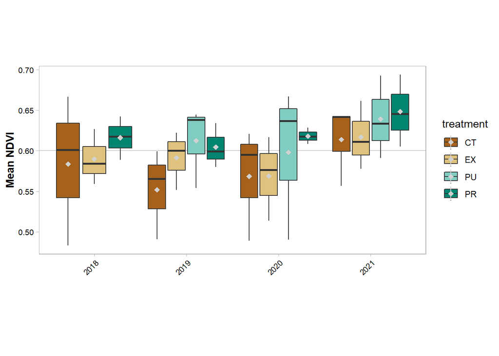

```r
TV_NDVI_avg$treatment <- factor(TV_NDVI_avg$treatment, levels = c("CT", "EX", "PU", "PR"))

  ggplot(TV_NDVI_avg, aes(x= year, y=avg_NDVI, fill = treatment))+
    geom_hline(yintercept = 0.6, color="#D0CECE")+
      geom_boxplot(position=position_dodge(.85))+
    scale_fill_manual(values=c("CT" = "#a6611a",
                                "EX" = "#dfc27d",
                                "PU" = "#80cdc1",
                                "PR" = "#018571"))+
  stat_summary(fun.y="mean", color="#D1D1D1", size = .5, shape = 18, position=position_dodge(.85))+
     theme_light()+
     theme(panel.grid.major = element_blank(), panel.grid.minor = element_blank())+
     theme(axis.title.y = element_text(face = "bold"))+
     theme(axis.title.x = element_text(face = "bold"))+
     theme(plot.title = element_text(hjust = .5))+
     theme(axis.text.x = element_text(color = "black", size = 8, angle = 45, hjust = 1))+
     theme(axis.text.y = element_text(color = "black", size = 8))+
     theme(aspect.ratio = 9/18.5)+
  labs(y = "Mean NDVI", x = "")
```

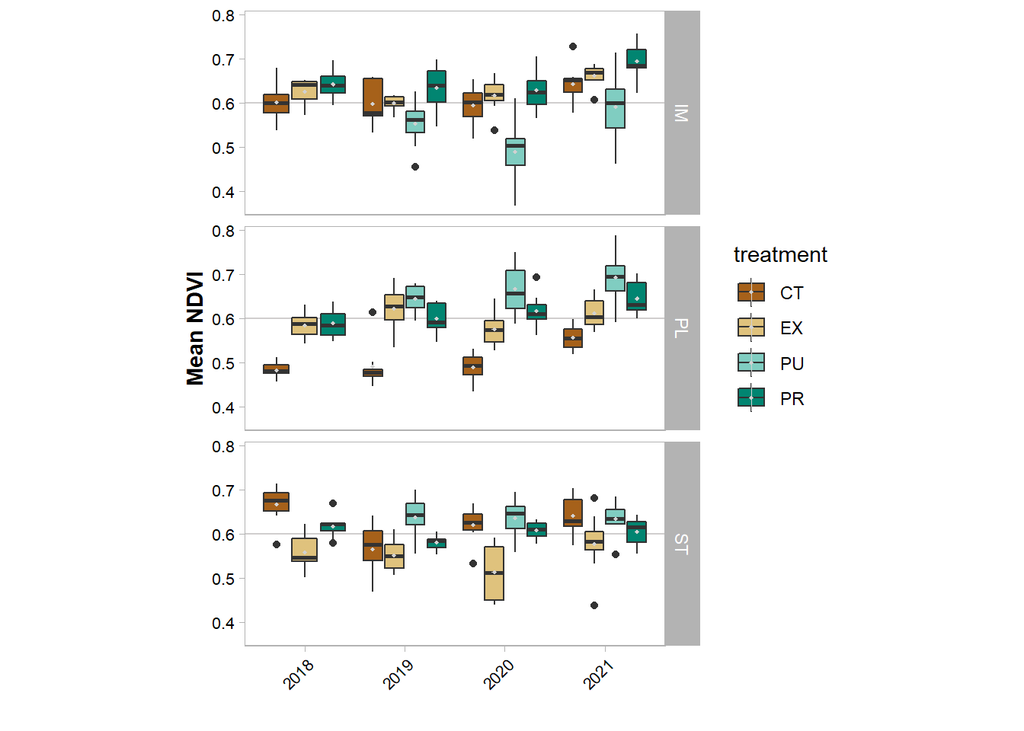

```r
    #theme(legend.position="bottom")

ggsave("../Figures/Teamvole_boxplot_NDVI.jpeg")
TV_NDVI_avg_rep$treatment <- factor(TV_NDVI_avg_rep$treatment, levels = c("CT", "EX", "PU", "PR"))

  ggplot(TV_NDVI_avg_rep, aes(x= year, y=NDVI_avg, fill = treatment))+
    geom_hline(yintercept = 0.6, color="#D0CECE")+
      geom_boxplot(position=position_dodge(.85))+
    scale_fill_manual(values=c("CT" = "#a6611a",
                                "EX" = "#dfc27d",
                                "PU" = "#80cdc1",
                                "PR" = "#018571"))+
    stat_summary(fun.y="mean", color="#D1D1D1", size = .1, shape = 18, position=position_dodge(.85))+
     theme_light()+
     theme(panel.grid.major = element_blank(), panel.grid.minor = element_blank())+
     theme(axis.title.y = element_text(face = "bold"))+
     theme(axis.title.x = element_text(face = "bold"))+
     theme(plot.title = element_text(hjust = .5))+
     theme(axis.text.x = element_text(color = "black", size = 8, angle = 45, hjust = 1))+
     theme(axis.text.y = element_text(color = "black", size = 8))+
     theme(aspect.ratio = 9/18.5)+
  labs(y = "Mean NDVI", x = "")+
    #theme(legend.position="bottom")+
     facet_grid(site ~ .)
```

```r
ggsave("../Figures/Teamvole_boxplot_NDVI_sites.jpeg")
```

## Load in Team Vole cover data

```r
TV_cover_orig <- read.csv("../Derived CSVs/TeamVole_relcov_funcgrp_ALL.csv", header = TRUE)
```

## Prep TV cover

1. Only looking at a few species, so the rest can be deleted
2. Need to change cover from long to wide format so it can be plot against NDVI data

```r
TV_cover_subset <- TV_cover_orig %>%
  select(year, site, treatment, quad, species, cover)%>%
  filter(species == "Eri vag" | species == "Bet nan" | species == "Rub cha") %>%
  pivot_wider(names_from = species, values_from = cover) %>%
  rename("Bet_nan" = "Bet nan", "Eri_vag" = "Eri vag", "Rub_cha" = "Rub cha") %>%
  mutate(year = as.character(year), quad = as.numeric(quad))
```

### Join NDVI and COVER data

Join the dataset, drop columns we don’t need, delete 2020 data as we don’t have cover for that year

```r
TV_join <- left_join(TV_NDVI_avg_rep, TV_cover_subset, by= c("year", "site", "treatment", "quad")) %>%
  select(-n, sd_rep) %>%
  filter(year != "2020")
```

### Scatter plot of NDVI vs species cover

Bet nan vs NDVI

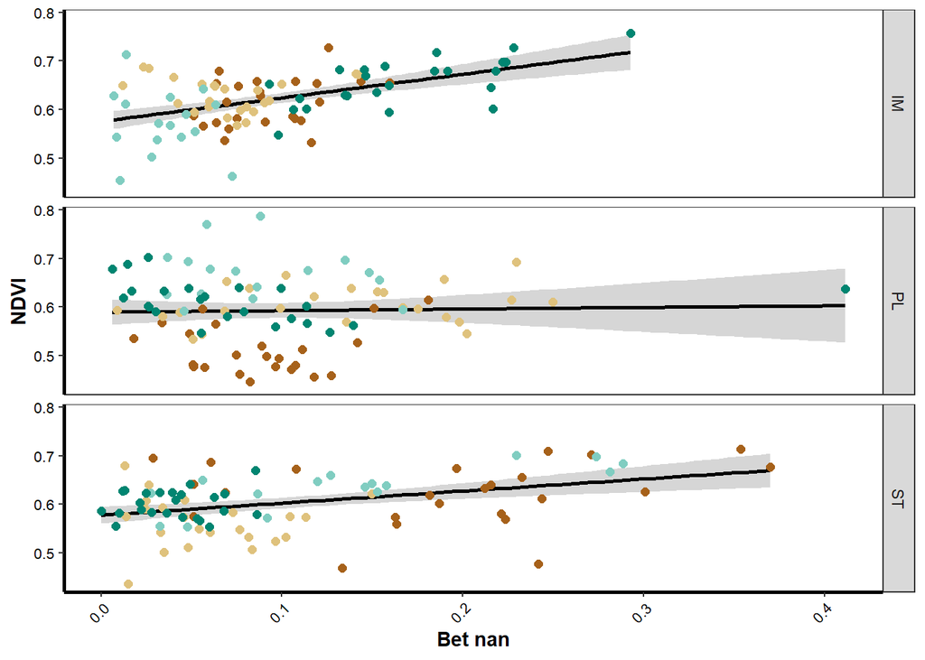

```r
highlight_CT <- TV_join %>% filter(treatment == "CT")
highlight_EX <- TV_join %>% filter(treatment == "EX")
highlight_PU <- TV_join %>% filter(treatment == "PU")
highlight_PR <- TV_join %>% filter(treatment == "PR")

ggplot(data = TV_join, aes(x = Bet_nan, y = NDVI_avg)) +
  geom_point(size = 2)+
  geom_smooth(method = "lm", se = TRUE, color = "black")+
   geom_point(data=highlight_CT, aes(x=Bet_nan,y=NDVI_avg), size = 2, color = "#a6611a")+
  geom_point(data=highlight_EX, aes(x=Bet_nan,y=NDVI_avg), size = 2, color = "#dfc27d")+
  geom_point(data=highlight_PU, aes(x=Bet_nan,y=NDVI_avg), size = 2, color = "#80cdc1")+
  geom_point(data=highlight_PR, aes(x=Bet_nan,y=NDVI_avg), size = 2, color = "#018571")+
  theme_bw() +
  theme(panel.grid.major = element_blank(),
panel.grid.minor = element_blank(), axis.line = element_line(colour = "black"))+
  theme(axis.text.x = element_text(color = "black", size = 8, angle = 45, hjust = 1))+
  theme(axis.text.y = element_text(color = "black", size = 8))+
  theme( axis.line = element_line(colour = "black",
                      size = 1, linetype = "solid"))+
  labs(y = "NDVI", x = "Bet nan")+
  theme(axis.title.y = element_text(face = "bold"))+
    theme(axis.title.x = element_text(face = "bold"))+
  #stat_regline_equation(label.x=0.3)+ #adds regression line equation
  #stat_cor(aes(label=..rr.label..), label.x=0.3)+ #adds R2
  #stat_cor(method = "pearson", label.x = .3)+ #adds p-value
  facet_grid(site ~ .)
```

```r
  #facet_grid(. ~ site)

#ggsave("../Figures/Teamvole_regrestion_Betnan_NDVI.jpeg")
```

Eri vag vs NDVI

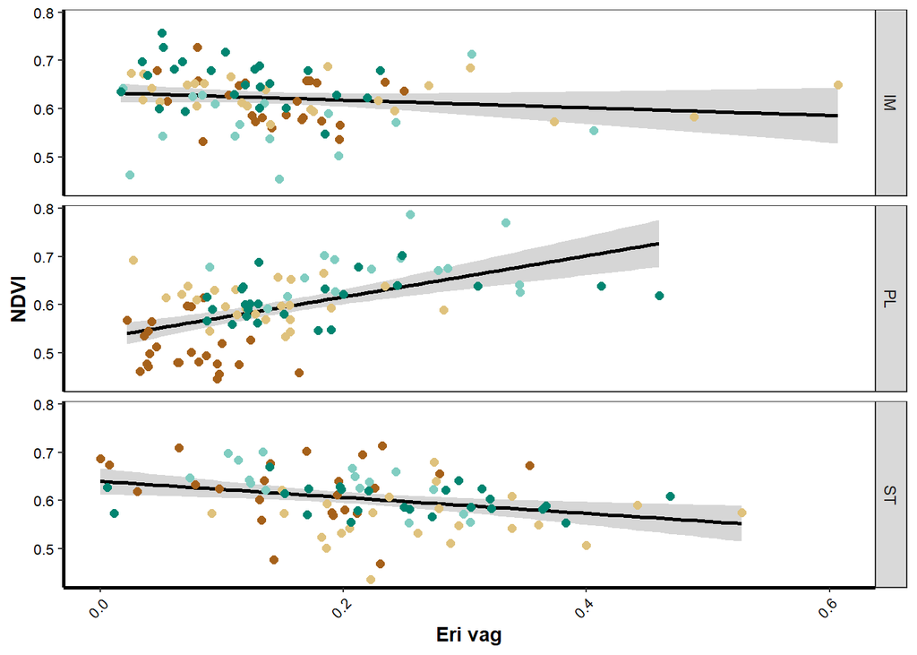

```r
highlight_CT <- TV_join %>% filter(treatment == "CT")
highlight_EX <- TV_join %>% filter(treatment == "EX")
highlight_PU <- TV_join %>% filter(treatment == "PU")
highlight_PR <- TV_join %>% filter(treatment == "PR")

ggplot(data = TV_join, aes(x = Eri_vag, y = NDVI_avg)) +
  geom_point(size = 2)+
  geom_smooth(method = "lm", se = TRUE, color = "black")+
   geom_point(data=highlight_CT, aes(x=Eri_vag,y=NDVI_avg), size = 2, color = "#a6611a")+
  geom_point(data=highlight_EX, aes(x=Eri_vag,y=NDVI_avg), size = 2, color = "#dfc27d")+
  geom_point(data=highlight_PU, aes(x=Eri_vag,y=NDVI_avg), size = 2, color = "#80cdc1")+
  geom_point(data=highlight_PR, aes(x=Eri_vag,y=NDVI_avg), size = 2, color = "#018571")+
  theme_bw() +
  theme(panel.grid.major = element_blank(),
panel.grid.minor = element_blank(), axis.line = element_line(colour = "black"))+
  theme(axis.text.x = element_text(color = "black", size = 8, angle = 45, hjust = 1))+
  theme(axis.text.y = element_text(color = "black", size = 8))+
  theme( axis.line = element_line(colour = "black",
                      size = 1, linetype = "solid"))+
  labs(y = "NDVI", x = "Eri vag")+
  theme(axis.title.y = element_text(face = "bold"))+
    theme(axis.title.x = element_text(face = "bold"))+
  #stat_regline_equation(label.x=0.3)+ #adds regression line equation
  #stat_cor(aes(label=..rr.label..), label.x=0.3)+ #adds R2
  #stat_cor(method = "pearson", label.x = .4)+ #adds p-value
  #theme(legend.position="bottom")+
  facet_grid(site ~ .)
```

```r
  #facet_grid(. ~ site)

ggsave("../Figures/Teamvole_regrestion_Erivag_NDVI.jpeg")
```

Rub cha vs NDVI

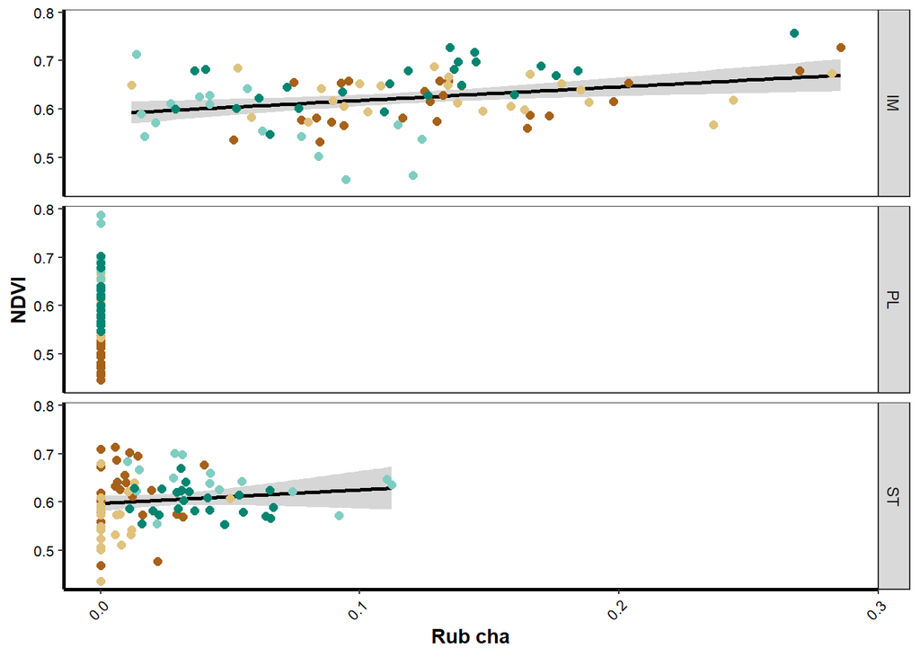

```r
highlight_CT <- TV_join %>% filter(treatment == "CT")
highlight_EX <- TV_join %>% filter(treatment == "EX")
highlight_PU <- TV_join %>% filter(treatment == "PU")
highlight_PR <- TV_join %>% filter(treatment == "PR")

ggplot(data = TV_join, aes(x = Rub_cha, y = NDVI_avg)) +
  geom_point(size = 2)+
  geom_smooth(method = "lm", se = TRUE, color = "black")+
   geom_point(data=highlight_CT, aes(x=Rub_cha,y=NDVI_avg), size = 2, color = "#a6611a")+
  geom_point(data=highlight_EX, aes(x=Rub_cha,y=NDVI_avg), size = 2, color = "#dfc27d")+
  geom_point(data=highlight_PU, aes(x=Rub_cha,y=NDVI_avg), size = 2, color = "#80cdc1")+
  geom_point(data=highlight_PR, aes(x=Rub_cha,y=NDVI_avg), size = 2, color = "#018571")+
  theme_bw() +
  theme(panel.grid.major = element_blank(),
panel.grid.minor = element_blank(), axis.line = element_line(colour = "black"))+
  theme(axis.text.x = element_text(color = "black", size = 8, angle = 45, hjust = 1))+
  theme(axis.text.y = element_text(color = "black", size = 8))+
  theme( axis.line = element_line(colour = "black",
                      size = 1, linetype = "solid"))+
  labs(y = "NDVI", x = "Rub cha")+
  theme(axis.title.y = element_text(face = "bold"))+
    theme(axis.title.x = element_text(face = "bold"))+
  #stat_regline_equation(label.x=0.2)+ #adds regression line equation
  #stat_cor(aes(label=..rr.label..), label.x=0.2)+ #adds R2
  #stat_cor(method = "pearson", label.x = .2)+ #adds p-value
  #theme(legend.position="bottom")+
  facet_grid(site ~ .)
```

```r
  #facet_grid(. ~ site)

ggsave("../Figures/Teamvole_regrestion_Rubcha_NDVI.jpeg")
```

# LTER NDVI/COVER

## Read in LTER NDVI data

Read in LTER NDVI data

```r
LTER_NDVI_orig <- read.csv("../Data/2011_2018_LMAT_NDVI.csv", header = TRUE)
```

## Prep the NDVI data

Subset by year, correct DOY column to reflect year

```r
LTER_NDVI_11 <- LTER_NDVI_orig %>% filter(year == "2011") %>%
  mutate(doy_adj = doy)

LTER_NDVI_14 <- LTER_NDVI_orig %>% filter(year == "2014")%>%
  mutate(doy_adj = doy+(365*3))

LTER_NDVI_15 <- LTER_NDVI_orig %>% filter(year == "2015")%>%
  mutate(doy_adj = doy+(365*4))

LTER_NDVI_16 <- LTER_NDVI_orig %>% filter(year == "2016")%>%
  mutate(doy_adj = doy+(365*5))

LTER_NDVI_17 <- LTER_NDVI_orig %>% filter(year == "2017")%>%
  mutate(doy_adj = doy+(365*6))

LTER_NDVI_18 <- LTER_NDVI_orig %>% filter(year == "2018")%>%
  mutate(doy_adj = doy+(365*7))
```

merge data back together

```r
LTER_NDVI_CLEAN           <- Reduce(MyMerge, list(LTER_NDVI_11, LTER_NDVI_14, LTER_NDVI_15, LTER_NDVI_16, LTER_NDVI_17, LTER_NDVI_18))

LTER_NDVI_CLEAN$time <- LTER_NDVI_CLEAN$time %>%
  recode("initial " = "initial")
```

## Line graph of NDVI

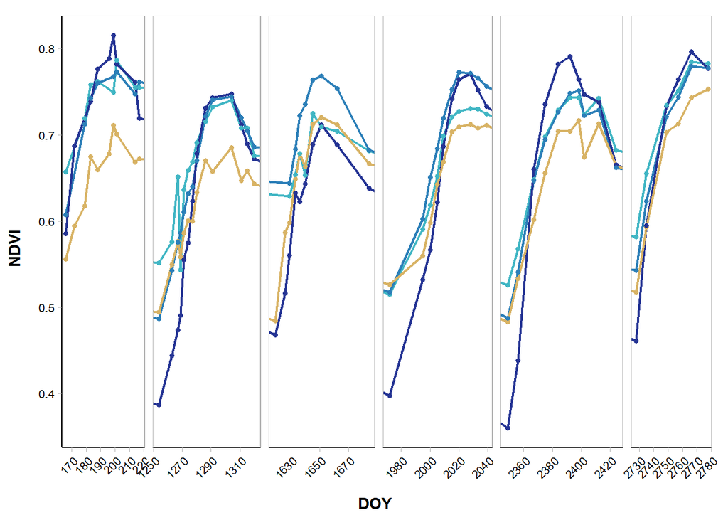

```r
#specify factor levels for fertilization and clipping treatments
LTER_NDVI_CLEAN$plot <- factor(LTER_NDVI_CLEAN$plot, levels = c("F2", "F5", "F10", "CT"))


ggplot(data = LTER_NDVI_CLEAN, aes(x = doy_adj, y = avg_ndvi, color = plot)) +
  scale_color_manual(values = c("CT" = "#d8b365",
                                "F2" = "#41b6c4",
                                "F5" = "#2c7fb8",
                                "F10" = "#253494"))+

  theme_light()+
  theme(panel.grid.major = element_blank(),
        panel.grid.minor = element_blank(),
        axis.text.x = element_text(color = "black", size = 8, angle = 45, hjust = 1),
        axis.text.y = element_text(color = "black", size = 8),
        axis.line = element_line(colour = "black", linetype = "solid"),
        legend.position="none",
        plot.title = element_text(hjust = .5))+
  geom_line(size = .75) +
  geom_point(size = 1.25) +
  labs(y = "NDVI", x = "DOY")+
  theme(axis.title.y = element_text(face = "bold"))+
  theme(axis.title.x = element_text(face = "bold"))+
  scale_x_break(c(218, 1253)) +
  scale_x_break(c(1321, 1618)) +
  scale_x_break(c(1685, 1971)) +
  scale_x_break(c(2040, 2348)) +
  scale_x_break(c(2425, 2727))
```

```r
ggsave("../Figures//LTER_NDVI_linegraph.jpeg")
```

## Read in LTER cover data

```r
LTER_cover_orig <- read.csv("../Derived CSVs/LTER_06MAT_relcov_funcgrp_allyrs.csv", header = TRUE)
```

## Prep the cover data

Subset by year based on # of quads measured per plot in a given year

- In 2008 we measured 4 quadrants/plot
- In 2015 & 2020 we measured with 5 quadrants/plot
- In all other years we measured with 8 quadrants

```r
Q4 <- subset(LTER_cover_orig, year== "2008")
Q5 <- subset(LTER_cover_orig, year== "2015" | year== "2020")
Q8 <- subset(LTER_cover_orig, year== "2010" | year== "2011" | year== "2012" | year== "2013" | year== "2014" | year== "2016" | year== "2017" | year== "2018" | year== "2019" |year== "2010" |year== "2021")
```

Sum across quadrats in a plot

```r
Q4_sum_avg_quad <- (Q4) %>%
  group_by(year, block, plot, species) %>%
  summarise_at(vars(rel_cov), list(sum_quad = sum), na.rm = TRUE)

Q5_sum_avg_quad <- (Q5) %>%
  group_by(year, block, plot, species)%>%
summarise_at(vars(rel_cov), list(sum_quad = sum), na.rm = TRUE)

Q8_sum_avg_quad <- (Q8) %>%
  group_by(year, block, plot, species) %>%
  summarise_at(vars(rel_cov), list(sum_quad = sum), na.rm = TRUE)
```

Create functions/vectors for calculating average rel_cov bases on # of quadrats then fill a new column with the average

```r
avg_Q4_quad <- c(Q4_sum_avg_quad$sum_quad/4)
avg_Q5_quad <- c(Q5_sum_avg_quad$sum_quad/5)
avg_Q8_quad <- c(Q8_sum_avg_quad$sum_quad/8)

#creates and fills a new column with the average (by diving that sum by the number of reps specified)
Q4_sum_avg_quad["avg_quad"] <-avg_Q4_quad
Q5_sum_avg_quad["avg_quad"] <-avg_Q5_quad
Q8_sum_avg_quad["avg_quad"] <-avg_Q8_quad
```

Merge all the years back together

```r
MyMerge       <- function(x, y){
  df            <- merge(x, y, all = TRUE)
  rownames(df)  <- df$Row.names
  df$Row.names  <- NULL
  return(df)
}
Avg_quad           <- Reduce(MyMerge, list(Q4_sum_avg_quad, Q5_sum_avg_quad, Q8_sum_avg_quad))
```

Average across blocks

```r
Avg_block <- (Avg_quad) %>%
  group_by(year, plot, species) %>%
  summarise_at(vars(avg_quad), list(avg_block = mean, block_sd = sd), na.rm = TRUE)
```

```r
LTER_cover_CLEAN <- Avg_block %>%
  filter(species == "Bet nan" | species == "Eri vag" | species == "Rub cha") %>%
  select(-block_sd)
```

### Join NDVI and COVER data

Join the dataset, drop columns we don’t need

```r
NDVI_initial <- LTER_NDVI_CLEAN %>%
  filter(time == "initial")

LTER_initial <- left_join(NDVI_initial,LTER_cover_CLEAN, by= c("year", "plot")) %>%
  select(-doy_adj, -doy) %>%
  pivot_wider(names_from = species, values_from = avg_block) %>%
  rename("Bet_nan" = "Bet nan", "Eri_vag" = "Eri vag", "Rub_cha" = "Rub cha")

#######

NDVI_half <- LTER_NDVI_CLEAN %>%
  filter(time == "half")

LTER_half <- left_join(NDVI_half,LTER_cover_CLEAN, by= c("year", "plot")) %>%
  select(-doy_adj, -doy)%>%
  pivot_wider(names_from = species, values_from = avg_block) %>%
  rename("Bet_nan" = "Bet nan", "Eri_vag" = "Eri vag", "Rub_cha" = "Rub cha")

#######

NDVI_peak <- LTER_NDVI_CLEAN %>%
  filter(time == "peak")

LTER_peak <- left_join(NDVI_peak,LTER_cover_CLEAN, by= c("year", "plot")) %>%
  select(-doy_adj, -doy)%>%
  pivot_wider(names_from = species, values_from = avg_block) %>%
  rename("Bet_nan" = "Bet nan", "Eri_vag" = "Eri vag", "Rub_cha" = "Rub cha")

#######

NDVI_post <- LTER_NDVI_CLEAN %>%
  filter(time == "post-peak")

LTER_post <- left_join(NDVI_post,LTER_cover_CLEAN, by= c("year", "plot")) %>%
  select(-doy_adj, -doy)%>%
  pivot_wider(names_from = species, values_from = avg_block) %>%
  rename("Bet_nan" = "Bet nan", "Eri_vag" = "Eri vag", "Rub_cha" = "Rub cha")
```

### Scatter plot of NDVI vs species cover

#### Bet nan vs NDVI

INITIAL

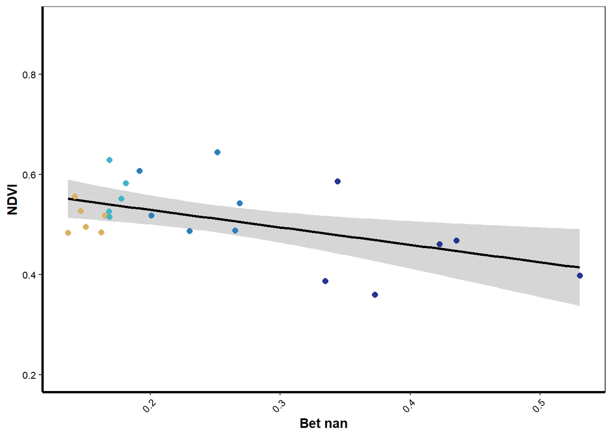

```r
#specify factor levels for treatments
LTER_initial$plot <- factor(LTER_initial$plot, levels = c("CT","F2","F5","F10"))

highlight_CT_in <- LTER_initial %>% filter(plot == "CT")
highlight_F2_in <- LTER_initial %>% filter(plot == "F2")
highlight_F5_in <- LTER_initial %>% filter(plot == "F5")
highlight_F10_in <- LTER_initial %>% filter(plot == "F10")

Bet_nan_initial <-  ggplot(data = LTER_initial, aes(x = Bet_nan, y = avg_ndvi)) +
  geom_point(size = 2)+
    geom_smooth(method = "lm", se = TRUE, color = "black")+
  geom_point(data=highlight_CT_in, aes(x=Bet_nan,y=avg_ndvi), size = 2, color = "#d8b365")+
  geom_point(data=highlight_F2_in, aes(x=Bet_nan,y=avg_ndvi), size = 2, color = "#41b6c4")+
  geom_point(data=highlight_F5_in, aes(x=Bet_nan,y=avg_ndvi), size = 2, color = "#2c7fb8")+
  geom_point(data=highlight_F10_in, aes(x=Bet_nan,y=avg_ndvi), size = 2, color = "#253494")+
  theme_bw() +
  theme(panel.grid.major = element_blank(),
panel.grid.minor = element_blank(), axis.line = element_line(colour = "black"))+
  theme(axis.text.x = element_text(color = "black", size = 8, angle = 45, hjust = 1))+
  theme(axis.text.y = element_text(color = "black", size = 8))+
  theme( axis.line = element_line(colour = "black",
                      size = 1, linetype = "solid"))+
  labs(y = "NDVI", x = "Bet nan")+
  theme(axis.title.y = element_text(face = "bold"))+
    theme(axis.title.x = element_text(face = "bold"))+
  ylim(0.2, 0.9)+
  #stat_regline_equation(label.x=0.3)+ #adds regression line equation
  #stat_cor(aes(label=..rr.label..), label.x=0.35)+ #adds R2
  #stat_cor(method = "pearson", label.x = .3)+ #adds p-value
  theme(legend.position="none")


print(Bet_nan_initial)
```

HALF

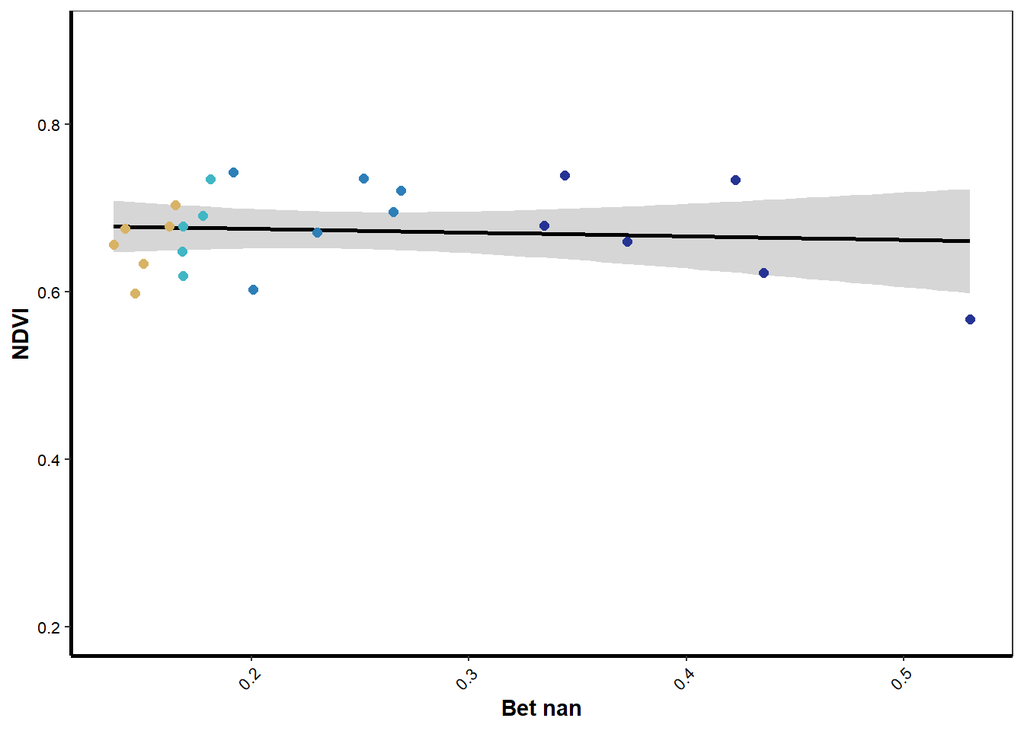

```r
#specify factor levels for treatments
LTER_half$plot <- factor(LTER_half$plot, levels = c("CT","F2","F5","F10"))

highlight_CT_half <- LTER_half %>% filter(plot == "CT")
highlight_F2_half <- LTER_half %>% filter(plot == "F2")
highlight_F5_half <- LTER_half %>% filter(plot == "F5")
highlight_F10_half <- LTER_half %>% filter(plot == "F10")

Bet_nan_half <-  ggplot(data = LTER_half, aes(x = Bet_nan, y = avg_ndvi)) +
  geom_point(size = 2)+
    geom_smooth(method = "lm", se = TRUE, color = "black")+
  geom_point(data=highlight_CT_half, aes(x=Bet_nan,y=avg_ndvi), size = 2, color = "#d8b365")+
  geom_point(data=highlight_F2_half, aes(x=Bet_nan,y=avg_ndvi), size = 2, color = "#41b6c4")+
  geom_point(data=highlight_F5_half, aes(x=Bet_nan,y=avg_ndvi), size = 2, color = "#2c7fb8")+
  geom_point(data=highlight_F10_half, aes(x=Bet_nan,y=avg_ndvi), size = 2, color = "#253494")+
  theme_bw() +
  theme(panel.grid.major = element_blank(),
panel.grid.minor = element_blank(), axis.line = element_line(colour = "black"))+
  theme(axis.text.x = element_text(color = "black", size = 8, angle = 45, hjust = 1))+
  theme(axis.text.y = element_text(color = "black", size = 8))+
  theme( axis.line = element_line(colour = "black",
                      size = 1, linetype = "solid"))+
  labs(y = "NDVI", x = "Bet nan")+
  theme(axis.title.y = element_text(face = "bold"))+
    theme(axis.title.x = element_text(face = "bold"))+
  ylim(0.2, 0.9)+
  #stat_regline_equation(label.x=0.3)+ #adds regression line equation
  #stat_cor(aes(label=..rr.label..), label.x=0.35)+ #adds R2
  #stat_cor(method = "pearson", label.x = .3)+ #adds p-value
  theme(legend.position="none")


print(Bet_nan_half)
```

PEAK

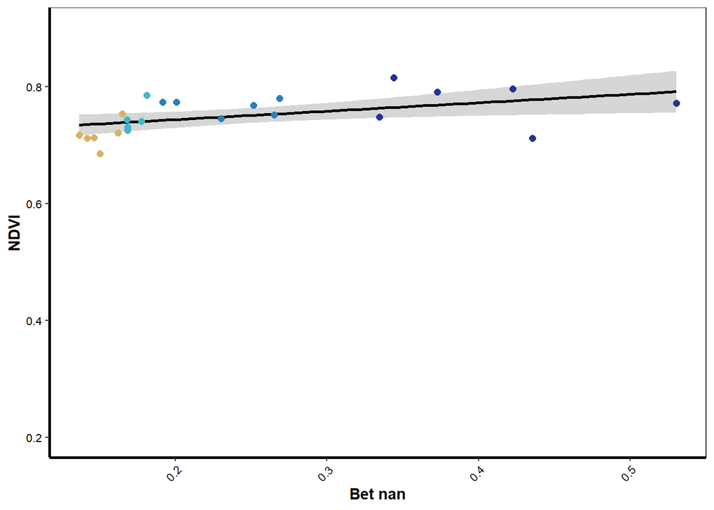

```r
#specify factor levels for treatments
LTER_peak$plot <- factor(LTER_peak$plot, levels = c("CT","F2","F5","F10"))

highlight_CT_peak <- LTER_peak %>% filter(plot == "CT")
highlight_F2_peak <- LTER_peak %>% filter(plot == "F2")
highlight_F5_peak <- LTER_peak %>% filter(plot == "F5")
highlight_F10_peak <- LTER_peak %>% filter(plot == "F10")


Bet_nan_peak <-  ggplot(data = LTER_peak, aes(x = Bet_nan, y = avg_ndvi)) +
  geom_point(size = 2)+
    geom_smooth(method = "lm", se = TRUE, color = "black")+
  geom_point(data=highlight_CT_peak, aes(x=Bet_nan,y=avg_ndvi), size = 2, color = "#d8b365")+
  geom_point(data=highlight_F2_peak, aes(x=Bet_nan,y=avg_ndvi), size = 2, color = "#41b6c4")+
  geom_point(data=highlight_F5_peak, aes(x=Bet_nan,y=avg_ndvi), size = 2, color = "#2c7fb8")+
  geom_point(data=highlight_F10_peak, aes(x=Bet_nan,y=avg_ndvi), size = 2, color = "#253494")+
  theme_bw() +
  theme(panel.grid.major = element_blank(),
panel.grid.minor = element_blank(), axis.line = element_line(colour = "black"))+
  theme(axis.text.x = element_text(color = "black", size = 8, angle = 45, hjust = 1))+
  theme(axis.text.y = element_text(color = "black", size = 8))+
  theme( axis.line = element_line(colour = "black",
                      size = 1, linetype = "solid"))+
  labs(y = "NDVI", x = "Bet nan")+
  theme(axis.title.y = element_text(face = "bold"))+
    theme(axis.title.x = element_text(face = "bold"))+
  ylim(0.2, 0.9)+
  #stat_regline_equation(label.x=0.3)+ #adds regression line equation
  #stat_cor(aes(label=..rr.label..), label.x=0.35)+ #adds R2
  #stat_cor(method = "pearson", label.x = .3)+ #adds p-value
  theme(legend.position="none")


print(Bet_nan_peak)
```

POST-PEAK

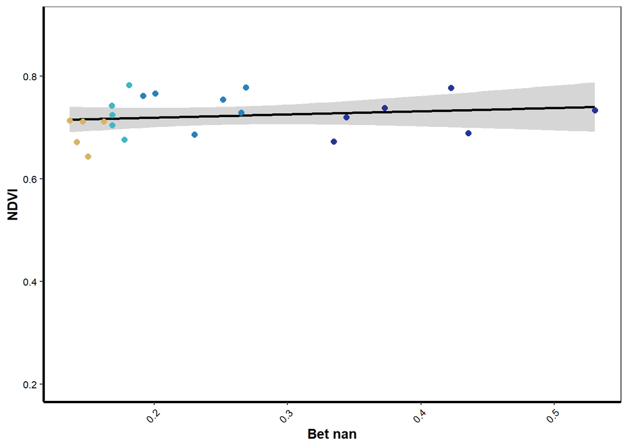

```r
#specify factor levels for treatments
LTER_post$plot <- factor(LTER_post$plot, levels = c("CT","F2","F5","F10"))

highlight_CT_post <- LTER_post %>% filter(plot == "CT")
highlight_F2_post <- LTER_post %>% filter(plot == "F2")
highlight_F5_post <- LTER_post %>% filter(plot == "F5")
highlight_F10_post <- LTER_post %>% filter(plot == "F10")


Bet_nan_post <-  ggplot(data = LTER_post, aes(x = Bet_nan, y = avg_ndvi)) +
  geom_point(size = 2)+
    geom_smooth(method = "lm", se = TRUE, color = "black")+
  geom_point(data=highlight_CT_post, aes(x=Bet_nan,y=avg_ndvi), size = 2, color = "#d8b365")+
  geom_point(data=highlight_F2_post, aes(x=Bet_nan,y=avg_ndvi), size = 2, color = "#41b6c4")+
  geom_point(data=highlight_F5_post, aes(x=Bet_nan,y=avg_ndvi), size = 2, color = "#2c7fb8")+
  geom_point(data=highlight_F10_post, aes(x=Bet_nan,y=avg_ndvi), size = 2, color = "#253494")+
  theme_bw() +
  theme(panel.grid.major = element_blank(),
panel.grid.minor = element_blank(), axis.line = element_line(colour = "black"))+
  theme(axis.text.x = element_text(color = "black", size = 8, angle = 45, hjust = 1))+
  theme(axis.text.y = element_text(color = "black", size = 8))+
  theme( axis.line = element_line(colour = "black",
                      size = 1, linetype = "solid"))+
  labs(y = "NDVI", x = "Bet nan")+
  theme(axis.title.y = element_text(face = "bold"))+
    theme(axis.title.x = element_text(face = "bold"))+
  ylim(0.2, 0.9)+
  #stat_regline_equation(label.x=0.3)+ #adds regression line equation
  #stat_cor(aes(label=..rr.label..), label.x=0.35)+ #adds R2
  #stat_cor(method = "pearson", label.x = .3)+ #adds p-value
  theme(legend.position="none")


print(Bet_nan_post)
```

Combine the graphs

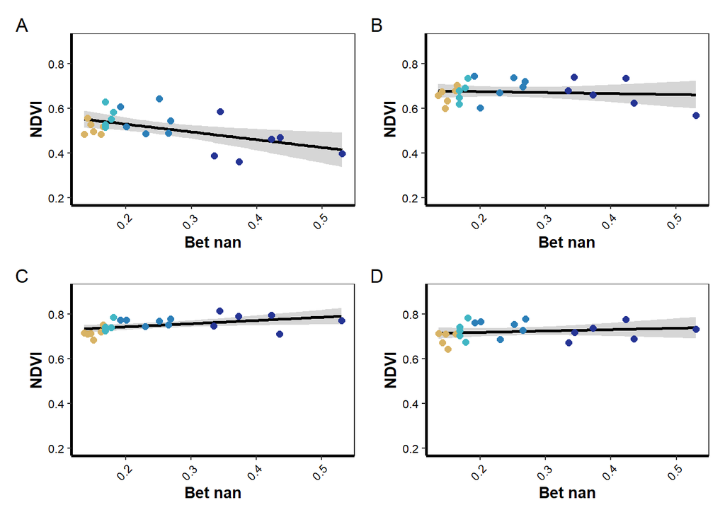

```r
(Bet_nan_initial+Bet_nan_half)/(Bet_nan_peak+Bet_nan_post) + plot_annotation(tag_levels = 'A')
```

```r
ggsave("../Figures/LTER_Betnan_NDVI_reg.jpg")
```

#### Eri vag vs NDVI

INITIAL

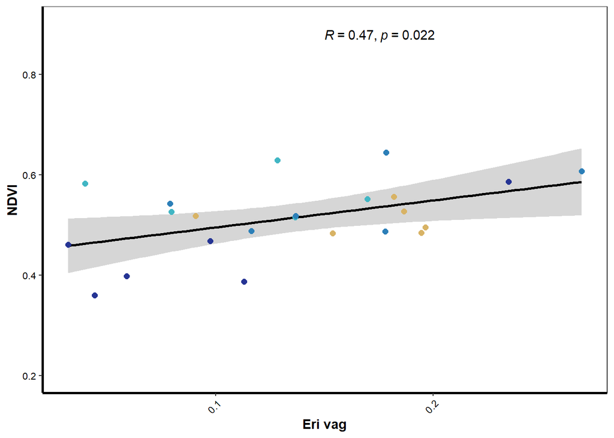

```r
#specify factor levels for treatments
LTER_initial$plot <- factor(LTER_initial$plot, levels = c("CT","F2","F5","F10"))

highlight_CT_in <- LTER_initial %>% filter(plot == "CT")
highlight_F2_in <- LTER_initial %>% filter(plot == "F2")
highlight_F5_in <- LTER_initial %>% filter(plot == "F5")
highlight_F10_in <- LTER_initial %>% filter(plot == "F10")


Eri_vag_in <-  ggplot(data = LTER_initial, aes(x = Eri_vag, y = avg_ndvi)) +
  geom_point(size = 2)+
    geom_smooth(method = "lm", se = TRUE, color = "black")+
  geom_point(data=highlight_CT_in, aes(x=Eri_vag,y=avg_ndvi), size = 2, color = "#d8b365")+
  geom_point(data=highlight_F2_in, aes(x=Eri_vag,y=avg_ndvi), size = 2, color = "#41b6c4")+
  geom_point(data=highlight_F5_in, aes(x=Eri_vag,y=avg_ndvi), size = 2, color = "#2c7fb8")+
  geom_point(data=highlight_F10_in, aes(x=Eri_vag,y=avg_ndvi), size = 2, color = "#253494")+
  theme_bw() +
  theme(panel.grid.major = element_blank(),
panel.grid.minor = element_blank(), axis.line = element_line(colour = "black"))+
  theme(axis.text.x = element_text(color = "black", size = 8, angle = 45, hjust = 1))+
  theme(axis.text.y = element_text(color = "black", size = 8))+
  theme( axis.line = element_line(colour = "black",
                      size = 1, linetype = "solid"))+
  labs(y = "NDVI", x = "Eri vag")+
  theme(axis.title.y = element_text(face = "bold"))+
    theme(axis.title.x = element_text(face = "bold"))+
  ylim(0.2, 0.9)+
  #stat_regline_equation(label.x=0.3)+ #adds regression line equation
  #stat_cor(aes(label=..rr.label..), label.x=0.35)+ #adds R2
  stat_cor(method = "pearson", label.x = .15)+ #adds p-value
  theme(legend.position="none")


print(Eri_vag_in)
```

HALF

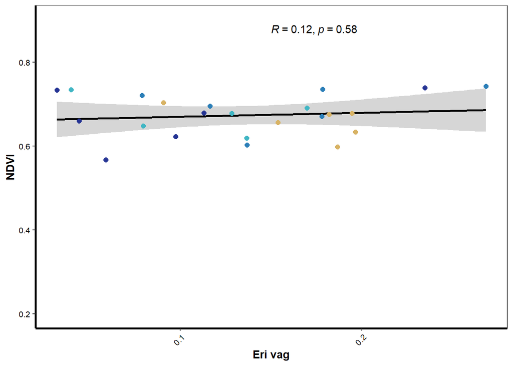

```r
#specify factor levels for treatments
LTER_half$plot <- factor(LTER_half$plot, levels = c("CT","F2","F5","F10"))

highlight_CT_half <- LTER_half %>% filter(plot == "CT")
highlight_F2_half <- LTER_half %>% filter(plot == "F2")
highlight_F5_half <- LTER_half %>% filter(plot == "F5")
highlight_F10_half <- LTER_half %>% filter(plot == "F10")


Eri_vag_half <-  ggplot(data = LTER_half, aes(x = Eri_vag, y = avg_ndvi)) +
  geom_point(size = 2)+
    geom_smooth(method = "lm", se = TRUE, color = "black")+
  geom_point(data=highlight_CT_half, aes(x=Eri_vag,y=avg_ndvi), size = 2, color = "#d8b365")+
  geom_point(data=highlight_F2_half, aes(x=Eri_vag,y=avg_ndvi), size = 2, color = "#41b6c4")+
  geom_point(data=highlight_F5_half, aes(x=Eri_vag,y=avg_ndvi), size = 2, color = "#2c7fb8")+
  geom_point(data=highlight_F10_half, aes(x=Eri_vag,y=avg_ndvi), size = 2, color = "#253494")+
  theme_bw() +
  theme(panel.grid.major = element_blank(),
panel.grid.minor = element_blank(), axis.line = element_line(colour = "black"))+
  theme(axis.text.x = element_text(color = "black", size = 8, angle = 45, hjust = 1))+
  theme(axis.text.y = element_text(color = "black", size = 8))+
  theme( axis.line = element_line(colour = "black",
                      size = 1, linetype = "solid"))+
  labs(y = "NDVI", x = "Eri vag")+
  theme(axis.title.y = element_text(face = "bold"))+
    theme(axis.title.x = element_text(face = "bold"))+
  ylim(0.2, 0.9)+
  #stat_regline_equation(label.x=0.3)+ #adds regression line equation
  #stat_cor(aes(label=..rr.label..), label.x=0.35)+ #adds R2
  stat_cor(method = "pearson", label.x = .15)+ #adds p-value
  theme(legend.position="none")


print(Eri_vag_half)
```

PEAK

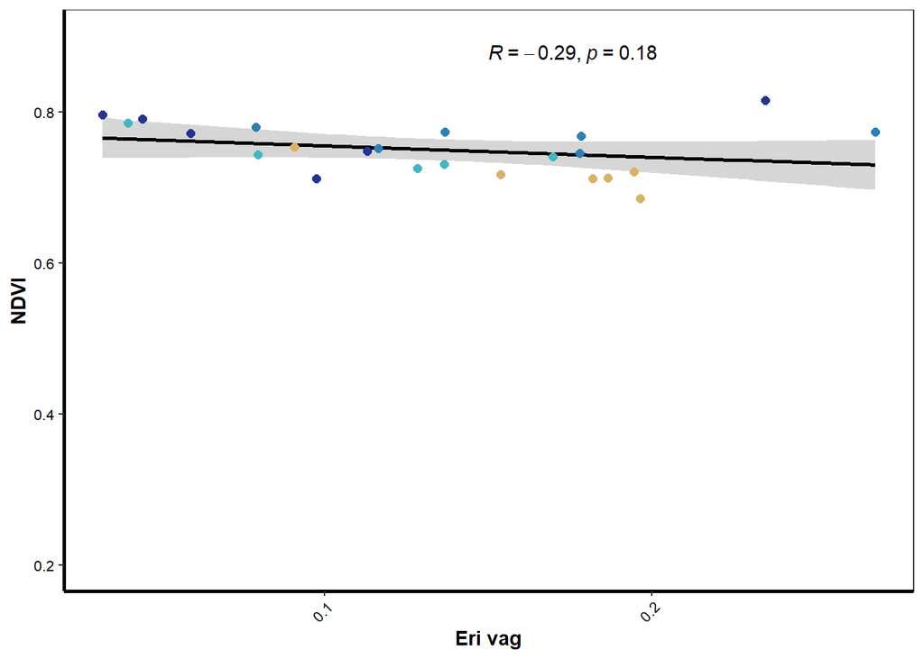

```r
#specify factor levels for treatments
LTER_peak$plot <- factor(LTER_peak$plot, levels = c("CT","F2","F5","F10"))

highlight_CT_peak <- LTER_peak %>% filter(plot == "CT")
highlight_F2_peak <- LTER_peak %>% filter(plot == "F2")
highlight_F5_peak <- LTER_peak %>% filter(plot == "F5")
highlight_F10_peak <- LTER_peak %>% filter(plot == "F10")


Eri_vag_peak <-  ggplot(data = LTER_peak, aes(x = Eri_vag, y = avg_ndvi)) +
  geom_point(size = 2)+
    geom_smooth(method = "lm", se = TRUE, color = "black")+
  geom_point(data=highlight_CT_peak, aes(x=Eri_vag,y=avg_ndvi), size = 2, color = "#d8b365")+
  geom_point(data=highlight_F2_peak, aes(x=Eri_vag,y=avg_ndvi), size = 2, color = "#41b6c4")+
  geom_point(data=highlight_F5_peak, aes(x=Eri_vag,y=avg_ndvi), size = 2, color = "#2c7fb8")+
  geom_point(data=highlight_F10_peak, aes(x=Eri_vag,y=avg_ndvi), size = 2, color = "#253494")+
  theme_bw() +
  theme(panel.grid.major = element_blank(),
panel.grid.minor = element_blank(), axis.line = element_line(colour = "black"))+
  theme(axis.text.x = element_text(color = "black", size = 8, angle = 45, hjust = 1))+
  theme(axis.text.y = element_text(color = "black", size = 8))+
  theme( axis.line = element_line(colour = "black",
                      size = 1, linetype = "solid"))+
  labs(y = "NDVI", x = "Eri vag")+
  theme(axis.title.y = element_text(face = "bold"))+
    theme(axis.title.x = element_text(face = "bold"))+
  ylim(0.2, 0.9)+
  #stat_regline_equation(label.x=0.3)+ #adds regression line equation
  #stat_cor(aes(label=..rr.label..), label.x=0.35)+ #adds R2
  stat_cor(method = "pearson", label.x = .15)+ #adds p-value
  theme(legend.position="none")


print(Eri_vag_peak)
```

POST-PEAK

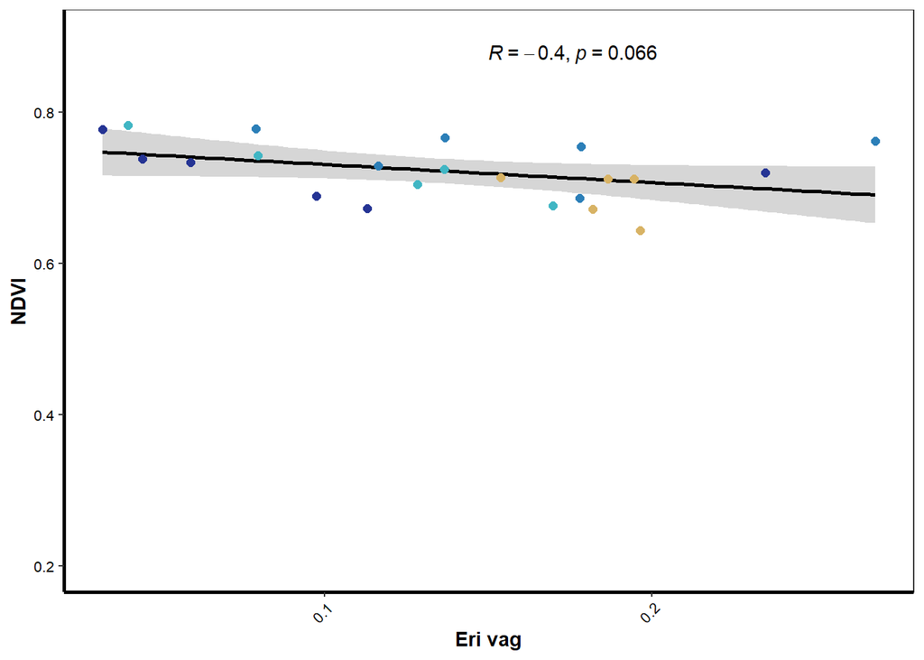

```r
#specify factor levels for treatments
LTER_post$plot <- factor(LTER_post$plot, levels = c("CT","F2","F5","F10"))

highlight_CT_post <- LTER_post %>% filter(plot == "CT")
highlight_F2_post <- LTER_post %>% filter(plot == "F2")
highlight_F5_post <- LTER_post %>% filter(plot == "F5")
highlight_F10_post <- LTER_post %>% filter(plot == "F10")


Eri_vag_post <-  ggplot(data = LTER_post, aes(x = Eri_vag, y = avg_ndvi)) +
  geom_point(size = 2)+
    geom_smooth(method = "lm", se = TRUE, color = "black")+
  geom_point(data=highlight_CT_post, aes(x=Eri_vag,y=avg_ndvi), size = 2, color = "#d8b365")+
  geom_point(data=highlight_F2_post, aes(x=Eri_vag,y=avg_ndvi), size = 2, color = "#41b6c4")+
  geom_point(data=highlight_F5_post, aes(x=Eri_vag,y=avg_ndvi), size = 2, color = "#2c7fb8")+
  geom_point(data=highlight_F10_post, aes(x=Eri_vag,y=avg_ndvi), size = 2, color = "#253494")+
  theme_bw() +
  theme(panel.grid.major = element_blank(),
panel.grid.minor = element_blank(), axis.line = element_line(colour = "black"))+
  theme(axis.text.x = element_text(color = "black", size = 8, angle = 45, hjust = 1))+
  theme(axis.text.y = element_text(color = "black", size = 8))+
  theme( axis.line = element_line(colour = "black",
                      size = 1, linetype = "solid"))+
  labs(y = "NDVI", x = "Eri vag")+
  theme(axis.title.y = element_text(face = "bold"))+
    theme(axis.title.x = element_text(face = "bold"))+
  ylim(0.2, 0.9)+
  #stat_regline_equation(label.x=0.3)+ #adds regression line equation
  #stat_cor(aes(label=..rr.label..), label.x=0.35)+ #adds R2
  stat_cor(method = "pearson", label.x = .15)+ #adds p-value
  theme(legend.position="none")


print(Eri_vag_post)
```

Combine the graphs

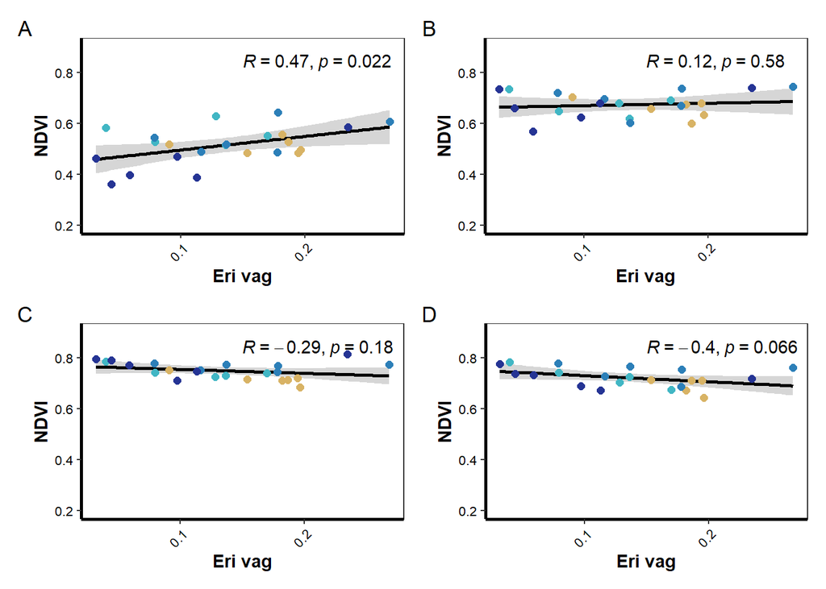

```r
(Eri_vag_in+Eri_vag_half)/(Eri_vag_peak+Eri_vag_post) + plot_annotation(tag_levels = 'A')
```

```r
ggsave("../Figures/LTER_Erivag_NDVI_reg.jpg")
```